# R Open Labs

## Introduction

#### University of North Carolina at Chapel Hill

#### September 20, 2018

## Data and other downloads

[Airbnb listings from Washington DC](http://guides.lib.unc.edu/ld.php?content_id=40263741)

## Today

This introductory workshop aims to cover:

- Reproducible workflow
  - importing data
  - scripts
  - projects
  - saving output
- [R for Data Science Chapters 4,6,8](http://r4ds.had.co.nz/workflow-basics.html)

## What is reproducibility?

1. Scientific reproducibility - if you repeat my experiment, you will get the same results as me. This is beyond the scope of this workshop ([see here for an overview](https://en.wikipedia.org/wiki/Replication_crisis))
2. Computational reproducibility - if I give you my data and code, you will get the same results as me. This is what we’ll focus on today

## Why does computational reproducibility matter?

1. Your most important collaborator is you six months from now.
2. We want Science (with a capital S) to be self-correcting. Since you’re human, you will make mistakes, so you want to make it as easy as possible for others to catch your errors (see [the Reinhart and Rogoff Excel error](https://theconversation.com/the-reinhart-rogoff-error-or-how-not-to-excel-at-economics-13646) and [the Guinea worm wars](https://www.cgdev.org/blog/mapping-worm-wars-what-public-should-take-away-scientific-debate-about-mass-deworming) for recent examples)

## Your script is real, your environment is not

For your results to be reproducible, every step you take to manipulate the data should be explicitly documented in an R script.

This also means that you want to make sure that your results don’t hidden/implicit dependencies on your R environment. There are two steps you can to take to prevent this.

1. Reconfigure RStudio not to save your workspace between sessions.

2. Restart RStudio from scratch and rerun the current script often.
   - Cmd/Ctrl + Shift + F10 to restart RStudio
   - Cmd/Ctrl + Shift + S to rerun the current script

Note: If you have learned R in the past, you may have been taught to use the expression rm(list = ls()) to clear your R environment. [This will not actually return R to a blank slate!](https://community.rstudio.com/t/first-line-of-every-r-script/799/12) Although this code will delete objects in your R environment, it won’t reset global settings that have been changed. It is always safer and more effective to restart RStudio.

## RStudio Projects

You can use the R function setwd() to point to locations of data files, but this isn’t ideal for reproducible research. When you switch between computers, it is likely that the **absolute** directory path will change, so you will have to modify the path for each computer. Users of your code will not have the same absolute directory path that you have, so they will have to modify the path in the setwd() function before they can use your code.

RStudio Projects provide a way to bundle together data, code, and other files together so that you can refer to files with **relative** directory paths, which creates a much more portable structure that won’t need to be modified between computers or users.

## Airbnb Data Analysis 1: Configuring the RStudio project

1. File > New Project > New Directory > New Project
2. Create a new subdirectory inside this project to store the data
3. Copy the Airbnb data (listings.csv) into this data directory
4. Create a new R Script for the data analysis in this project.

## Comments are your friend

In R, the # symbol indicates the beginning of a comment. Everything to the right of that is ignored by R, so you can write plain text to document what you’re doing, organize your code, and explain any tricky or unusual steps.

## Airbnb Data Analysis 2: Import the data

We’ll begin by loading the **tidyverse** library. This library includes **readr**, which we will use to read in our data file (for more details on readr, see Chapter 11 of the text).

RStudio has a useful keyboard shortcut for **<-** (the assignment operator): Alt+-, that is press the Alt key and the minus key at the same time.

```r
# Purpose: Exploratory data analysis of airbnb data
# Author: Nuvan Rathnayaka
# Date: September 2018

# Setup -----------------------------------------------------------
library(tidyverse)
# Data Import ------------------------------------------------------
airbnb_dc <- read_csv("data/listings.csv") #Since I'm using an RStudio project, I only have to specify the path relative to the top directory
```

## Aside on coding conventions

Something that I’ve glossed over is that you have options for how to name objects. For example, we called our imported data **airbnb_dc**, but we could have called it **airbnbListings**, or **airbnb.listings**

Having a consistent way you name objects and functions helps you remember what things are called. It’s especially useful when you’re working with others to agree upon a coding convention. There are many coding conventions you could choose. It doesn’t particularly matter which one you choose, as long as you choose a convention and stick to it.

To be consistent with the text, we will stick to the Tidyverse style guide: http://style.tidyverse.org/index.html

## Airbnb Data Analysis 3: Some useful commands

The dim() function will print the dimensions (rows x columns) of your data frame.

head() will print the first few rows of your data frame.

str() is a very general purpose function that will display the structure of an object. This is especially useful for debugging.

```r
# Some useful functions  ----------------------------------------
dim(airbnb_dc)
```

```
## [1] 7788   14
```

```r
head(airbnb_dc)
```

```
## # A tibble: 6 x 14
##       id name  property_type room_type accommodates bathrooms bedrooms
##    <int> <chr> <chr>         <chr>            <int>     <dbl>    <int>
## 1 4.87e6 Cozy… Apartment     Entire h…            3       1          0
## 2 1.67e7 Larg… Apartment     Entire h…            2       1          0
## 3 1.50e7 Newl… Apartment     Entire h…            2       1          1
## 4 5.96e6 Spac… Apartment     Entire h…            3       1          1
## 5 1.57e7 Luxu… Townhouse     Entire h…            4       2.5        2
## 6 4.02e6 Dupo… Apartment     Private …            2       2.5        1
## # ... with 7 more variables: price <dbl>, extra_people <dbl>,
## #   minimum_nights <int>, number_of_reviews <int>,
## #   review_scores_rating <int>, cancellation_policy <chr>,
## #   reviews_per_month <dbl>
```

```r
str(airbnb_dc)
```

```
## Classes 'tbl_df', 'tbl' and 'data.frame':    7788 obs. of  14 variables:
##  $ id                  : int  4873463 16736650 14999877 5955860 15655208 4022565 15968425 1301700 646183 14769106 ...
##  $ name                : chr  "Cozy Pied-a-Terre, the Heart of DC" "Large, welcoming studio in a central location" "Newly Renovated Apartment in the Heart of DC" "Spacious Dupont Circle Condo" ...
##  $ property_type       : chr  "Apartment" "Apartment" "Apartment" "Apartment" ...
##  $ room_type           : chr  "Entire home/apt" "Entire home/apt" "Entire home/apt" "Entire home/apt" ...
##  $ accommodates        : int  3 2 2 3 4 2 3 2 4 2 ...
##  $ bathrooms           : num  1 1 1 1 2.5 2.5 1 1 1 1 ...
##  $ bedrooms            : int  0 0 1 1 2 1 1 1 2 1 ...
##  $ price               : num  95 200 100 129 500 110 225 79 172 110 ...
##  $ extra_people        : num  10 0 0 50 0 15 20 0 0 10 ...
##  $ minimum_nights      : int  2 1 27 2 2 6 3 3 1 1 ...
##  $ number_of_reviews   : int  29 2 0 79 1 7 3 4 24 4 ...
##  $ review_scores_rating: int  94 90 NA 85 100 97 100 89 88 100 ...
##  $ cancellation_policy : chr  "flexible" "flexible" "moderate" "flexible" ...
##  $ reviews_per_month   : num  1.01 0.55 NA 3.13 1 0.23 0.82 0.09 0.48 0.67 ...
##  - attr(*, "spec")=List of 2
##   ..$ cols   :List of 14
##   .. ..$ id                  : list()
##   .. .. ..- attr(*, "class")= chr  "collector_integer" "collector"
##   .. ..$ name                : list()
##   .. .. ..- attr(*, "class")= chr  "collector_character" "collector"
##   .. ..$ property_type       : list()
##   .. .. ..- attr(*, "class")= chr  "collector_character" "collector"
##   .. ..$ room_type           : list()
##   .. .. ..- attr(*, "class")= chr  "collector_character" "collector"
##   .. ..$ accommodates        : list()
##   .. .. ..- attr(*, "class")= chr  "collector_integer" "collector"
##   .. ..$ bathrooms           : list()
##   .. .. ..- attr(*, "class")= chr  "collector_double" "collector"
##   .. ..$ bedrooms            : list()
##   .. .. ..- attr(*, "class")= chr  "collector_integer" "collector"
##   .. ..$ price               : list()
##   .. .. ..- attr(*, "class")= chr  "collector_double" "collector"
##   .. ..$ extra_people        : list()
##   .. .. ..- attr(*, "class")= chr  "collector_double" "collector"
##   .. ..$ minimum_nights      : list()
##   .. .. ..- attr(*, "class")= chr  "collector_integer" "collector"
##   .. ..$ number_of_reviews   : list()
##   .. .. ..- attr(*, "class")= chr  "collector_integer" "collector"
##   .. ..$ review_scores_rating: list()
##   .. .. ..- attr(*, "class")= chr  "collector_integer" "collector"
##   .. ..$ cancellation_policy : list()
##   .. .. ..- attr(*, "class")= chr  "collector_character" "collector"
##   .. ..$ reviews_per_month   : list()
##   .. .. ..- attr(*, "class")= chr  "collector_double" "collector"
##   ..$ default: list()
##   .. ..- attr(*, "class")= chr  "collector_guess" "collector"
##   ..- attr(*, "class")= chr "col_spec"
```

## What is an object in R? What is a class?

R is an **object-oriented programming language**. One way to understand how objects work in programming is to look at how objects work in real life.

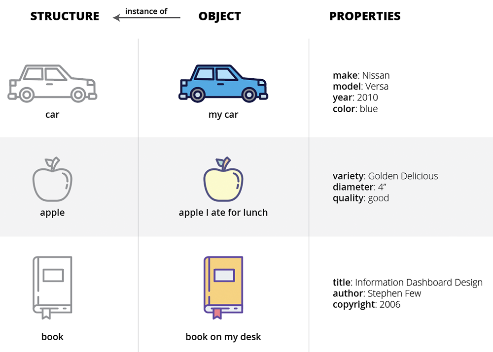

We tend to group objects by their structure. For example, there are many objects we call cars, and they all tend to share similarities in structure - they have wheels, windows, doors, etc. An *individual* car such as *my* car or *your* car is an **instance** of this structure. Cars also have a set of **properties** such as make, model, year and color. Each individual car has some variation of these properties.

Objects in R work in a similar way.

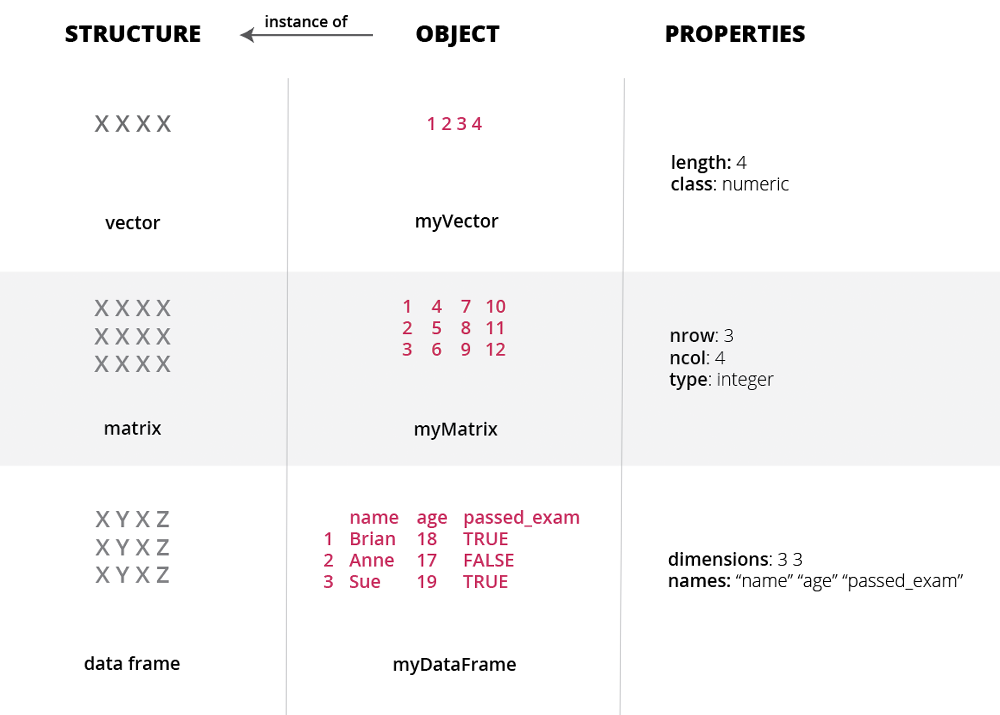

In the diagram above, we are looking at three **data structures** often used in R: **vectors**, **matrices** and **data frames**. We can create individual objects from these data structures, and those objects have their own properties. The way R defines what properties a given object has is through it’s **class**. You can think of a class as a contract between R and its users, defining the structure and properties of an object. People who develop R libraries take advantage of this system to customize the behavior of functions. Depending on which class an object belongs to, a custom function can be written. For example, type `print.` into your console

Even if you don’t plan on writing your own R libraries, this information can useful when you are debugging R code.

## Airbnb Data Analysis 4: Tables for categorical data

We can use the table() function to view counts/frequencies of categorical variables.

```r
# Categorical Variables  ----------------------------------------
table(airbnb_dc$property_type)
```

```
##
##          Apartment    Bed & Breakfast               Boat
##               4191                 73                  3
##     Boutique hotel           Bungalow              Cabin
##                 11                  4                  1
##             Castle        Condominium               Dorm
##                  1                420                 25
##        Guest suite         Guesthouse             Hostel
##                 11                 17                  2
##              House             In-law               Loft
##               2480                 12                 33
##              Other Serviced apartment          Timeshare
##                 31                  1                  1
##          Townhouse              Train          Treehouse
##                468                  1                  1
##              Villa
##                  1
```

As we saw in week 1, you can also next functions within each other. Here, let’s generate a contingency table using table(), then sort it by count using sort().

```r
sort(table(airbnb_dc$property_type), decreasing=TRUE)
```

```
##
##          Apartment              House          Townhouse
##               4191               2480                468
##        Condominium    Bed & Breakfast               Loft
##                420                 73                 33
##              Other               Dorm         Guesthouse
##                 31                 25                 17
##             In-law     Boutique hotel        Guest suite
##                 12                 11                 11
##           Bungalow               Boat             Hostel
##                  4                  3                  2
##              Cabin             Castle Serviced apartment
##                  1                  1                  1
##          Timeshare              Train          Treehouse
##                  1                  1                  1
##              Villa
##                  1
```

That works, but it’s a little hard to read. We could try breaking this into two steps and storing our intermediate output.

```r
property_type_table <- table(airbnb_dc$property_type)
sort(property_type_table, decreasing = TRUE)
```

```
##
##          Apartment              House          Townhouse
##               4191               2480                468
##        Condominium    Bed & Breakfast               Loft
##                420                 73                 33
##              Other               Dorm         Guesthouse
##                 31                 25                 17
##             In-law     Boutique hotel        Guest suite
##                 12                 11                 11
##           Bungalow               Boat             Hostel
##                  4                  3                  2
##              Cabin             Castle Serviced apartment
##                  1                  1                  1
##          Timeshare              Train          Treehouse
##                  1                  1                  1
##              Villa
##                  1
```

This works ok, but it does mean we’re creating an additional object, property_type_table, and we could end up with lots of objects that are trivially different from each other if we do this too often. In the next lesson, we’ll introduce the pipe operator, which makes this kind of nested computation easier to read.

Last week talked about different kinds of vectors. Recall, a vector is a column of data of a single type, and a data frame is a collection of vectors of the same length. Last week we introduced integer, numeric, character, and factor vectors. There’s another commonly used vector type: logical. This is just a vector of TRUE or FALSE values. Suppose we want to know whether a listings price is greater than 500.

```r
airbnb_dc$price > 500 #Note that since we're not assigning this vector to a variable, R displays it, but doesn't save it as an object in the environment.
```

```
##    [1] FALSE FALSE FALSE FALSE FALSE FALSE FALSE FALSE FALSE FALSE  TRUE
##   [12] FALSE FALSE FALSE FALSE FALSE FALSE FALSE FALSE FALSE FALSE  TRUE
##   [23] FALSE FALSE FALSE FALSE FALSE FALSE FALSE FALSE FALSE FALSE FALSE
##   [34] FALSE FALSE FALSE FALSE FALSE FALSE  TRUE FALSE FALSE FALSE FALSE
##   [45] FALSE FALSE FALSE FALSE FALSE FALSE FALSE FALSE FALSE FALSE FALSE
##   [56] FALSE FALSE FALSE FALSE FALSE FALSE FALSE FALSE FALSE FALSE FALSE
##   [67] FALSE  TRUE FALSE FALSE FALSE FALSE FALSE FALSE FALSE FALSE FALSE
##   [78]  TRUE FALSE FALSE FALSE  TRUE  TRUE FALSE FALSE FALSE FALSE  TRUE
##   [89] FALSE FALSE FALSE FALSE FALSE FALSE FALSE FALSE FALSE FALSE FALSE
##  [100] FALSE FALSE FALSE FALSE  TRUE FALSE FALSE FALSE FALSE FALSE FALSE
##  [111] FALSE FALSE FALSE FALSE  TRUE FALSE FALSE FALSE FALSE FALSE FALSE
##  [122] FALSE  TRUE  TRUE  TRUE FALSE FALSE FALSE FALSE FALSE FALSE FALSE
##  [133] FALSE FALSE FALSE FALSE FALSE  TRUE FALSE  TRUE FALSE FALSE FALSE
##  [144] FALSE FALSE FALSE FALSE FALSE  TRUE FALSE FALSE FALSE FALSE FALSE
##  [155] FALSE FALSE FALSE FALSE FALSE FALSE  TRUE FALSE FALSE FALSE FALSE
```

[output cut: 693 more lines]

You can see other logical operators [here](https://www.statmethods.net/management/operators.html).

We can feed this logical vector into the table() function to get a count of how many listings have prices above $500.

```r
table(airbnb_dc$price > 500)
```

```
##
## FALSE  TRUE
##  7029   759
```

We can also use the table function to look at the joint counts of multiple categorical variables. For example, if we want to look at the how many properties have prices above $500 across different property types.

```r
with(airbnb_dc, table(property_type, price > 500))
```

```
##
## property_type        FALSE TRUE
##   Apartment           3884  307
##   Bed & Breakfast       72    1
##   Boat                   3    0
##   Boutique hotel        11    0
##   Bungalow               4    0
##   Cabin                  1    0
##   Castle                 1    0
##   Condominium          356   64
##   Dorm                  25    0
##   Guest suite           11    0
##   Guesthouse            16    1
##   Hostel                 2    0
##   House               2150  330
##   In-law                12    0
##   Loft                  28    5
##   Other                 28    3
##   Serviced apartment     1    0
##   Timeshare              1    0
##   Townhouse            420   48
##   Train                  1    0
##   Treehouse              1    0
##   Villa                  1    0
```

## Airbnb Data Analysis 5: Exploring continuous data

R has built-in functions to compute the mean, standard deviation, min, median, and max.

```r
# Continuous Variables  ----------------------------------------

mean(airbnb_dc$price)
```

```
## [1] 247.1451
```

```r
sd(airbnb_dc$price)
```

```
## [1] 385.8856
```

```r
min(airbnb_dc$price)
```

```
## [1] 0
```

```r
median(airbnb_dc$price)
```

```
## [1] 125
```

```r
max(airbnb_dc$price)
```

```
## [1] 6000
```

R also has a built-in function to compute correlation coefficients. This let’s us explore the pairwise associations between continuous variables.

```r
with(airbnb_dc, cor(price, number_of_reviews))
```

```
## [1] -0.1560021
```

## Airbnb Data Analysis 6: Missing Data

There are some missing values in the review_scores_rating and reviews_per_month columns, even within the first six rows. We can check which values of review_scores_rating are NA with `is.na()`

```r
# Continuous Variables  ----------------------------------------


sum(is.na(airbnb_dc$review_scores_rating)) #summing a logical (TRUE/FALSE) vector counts the number of TRUE values
```

```
## [1] 2207
```

We can check all of our columns using R’s colSum to sum all of the columns at the same time.

```r
colSums(is.na(airbnb_dc))
```

```
##                   id                 name        property_type
##                    0                    5                    0
##            room_type         accommodates            bathrooms
##                    0                    0                   14
##             bedrooms                price         extra_people
##                   14                    0                    0
##       minimum_nights    number_of_reviews review_scores_rating
##                    0                    0                 2207
##  cancellation_policy    reviews_per_month
##                    0                 2128
```

Handling missing data is an advanced topic that is a bit beyond the scope of this lesson. There is no good way to handle missing data, there are only bad and less bad ways.

One of the bad ways to handle missing data is what’s known as a complete case analysis. In this kind of analysis, you only keep observations (rows) where you have observed (non-missing) values for ALL columns.

R has built-in functions to facilitate this:

- `complete.cases` returns a logical vector indicating whether or not an entire row of a dataset contains any missing values. You can also use this function on a subset of columns to determine if only those columns are complete
- `na.omit` returns a new dataframe with only the complete cases (as identified above)

For most R functions, the default is to return NA is any of the values are NA:

```r
mean(airbnb_dc$review_scores_rating)
```

```
## [1] NA
```

```r
with(airbnb_dc, cor(review_scores_rating, reviews_per_month))
```

```
## [1] NA
```

Some functions, like the linear regression function lm(), perform a complete-case analysis:

```r
lm(review_scores_rating~price, data=airbnb_dc)
```

```
##
## Call:
## lm(formula = review_scores_rating ~ price, data = airbnb_dc)
##
## Coefficients:
## (Intercept)        price
##   94.230536     0.003191
```

When a function complains about missing values and fails, there’s usually an argument that can be modified to change it to a complete-case analysis:

```r
mean(airbnb_dc$review_scores_rating, na.rm=TRUE)
```

```
## [1] 94.72406
```

```r
with(airbnb_dc, cor(review_scores_rating, reviews_per_month, use="pairwise.complete.obs"))
```

```
## [1] 0.09933035
```

Complete-case analysis is OK for exploratory data analysis, but if your goal is statistical inference, you’ll want to use a different method (e.g. multiple imputation using the mice library)

## Airbnb Data Analysis 7: ggplot

Last week, we introduced ggplot2 for statistical graphics. This library implements the grammar of graphics, which provides a structured, modular way to think about plots. The three most commonly altered components are:

- aesthetics - the visual properties of objects on the plot, e.g x location, y location, color, size
- geom - the geometric object used to represent your data, e.g. point, line, histogram
- facets - let you create subplots for each level of a categorical variable

Let’s look at a few examples. We can look at a histogram of review scores. Here, the only aesthetic we need to set is the x location, and then we can request a histogram.

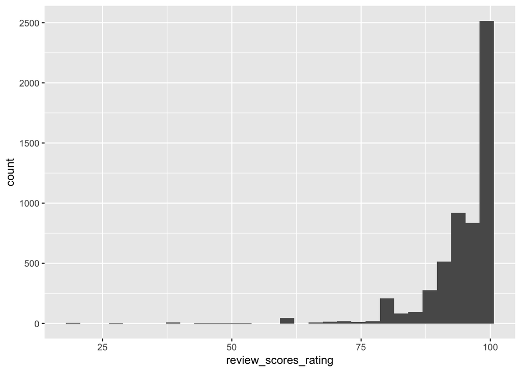

```r
ggplot(airbnb_dc, aes(x=review_scores_rating)) + geom_histogram()
```

To get a smoothed histogram (aka kernel density estimate), all we have to do is change to geom_density:

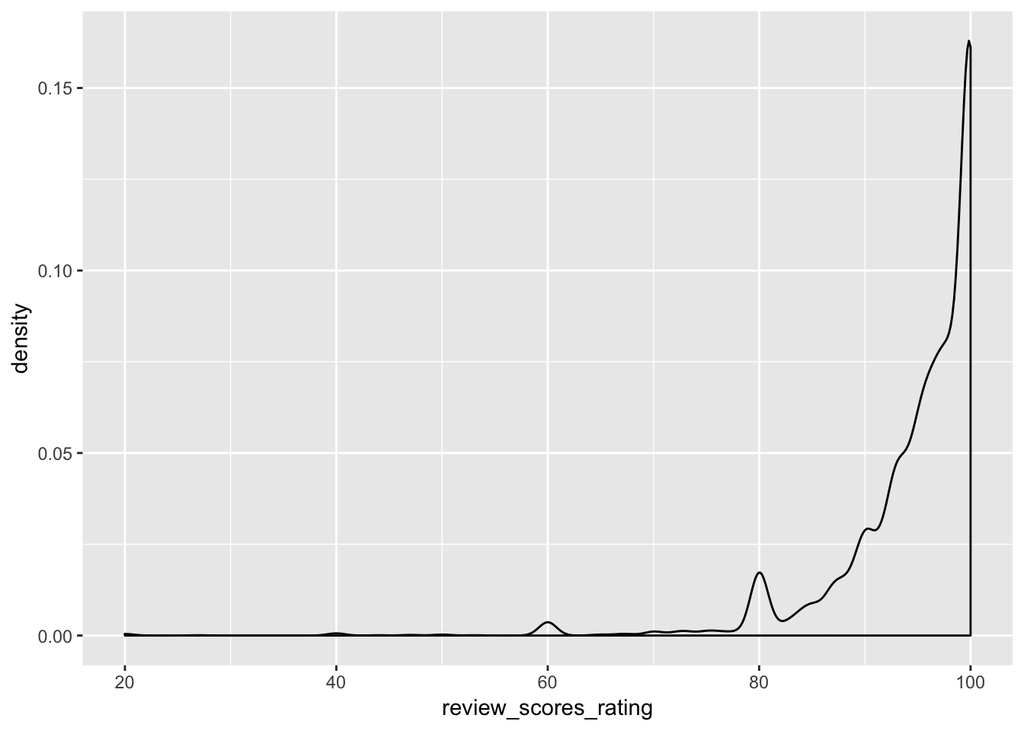

```r
ggplot(airbnb_dc, aes(x=review_scores_rating)) + geom_density()
```

If we want to look at the distribution of reviews across different room types, we could add a group aesthetic for the room_type variable:

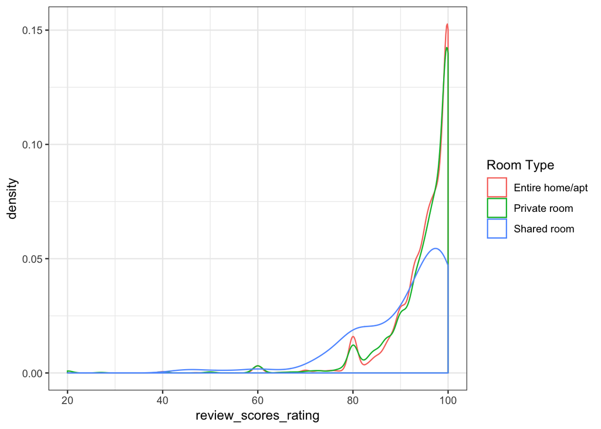

```r
ggplot(airbnb_dc, aes(x=review_scores_rating, color=room_type)) + geom_density() + guides(color=guide_legend(title="Room Type")) + theme_bw()
```

Since, there a lot of overlap, we could use facets to create a subplot for each room_type:

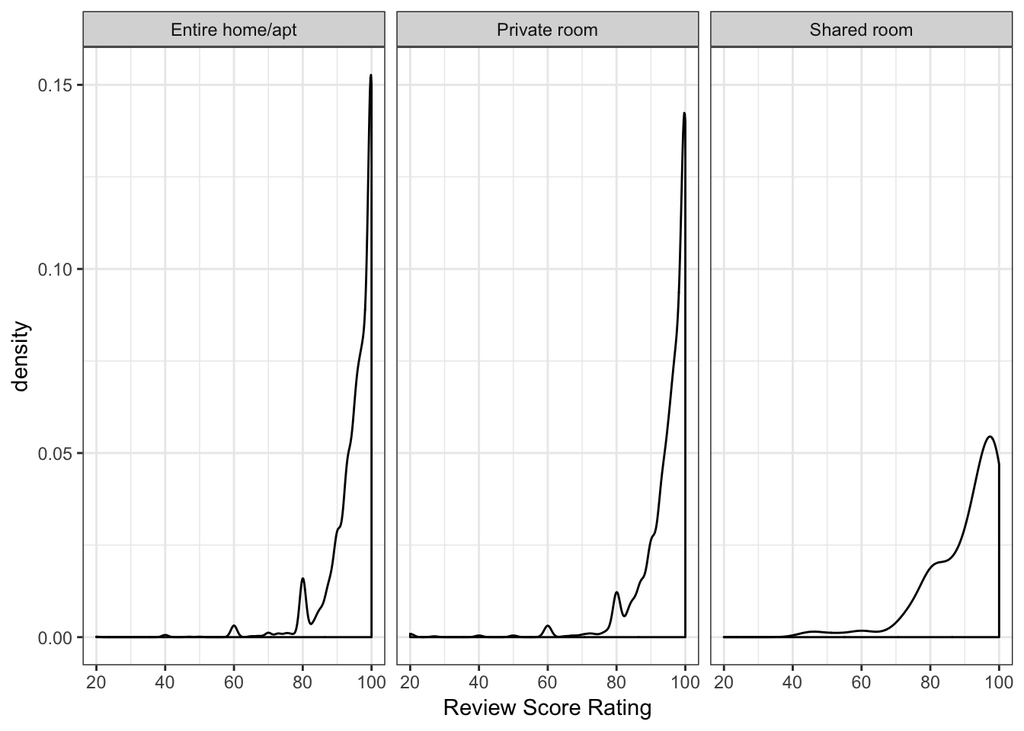

```r
ggplot(airbnb_dc, aes(x=review_scores_rating, color=)) + geom_density() + facet_wrap(~ room_type) + xlab("Review Score Rating") + theme_bw()
```

So far, we’ve looked a single continuous variable (review_scores_rating) as it related to a categorical variables (room_type). If we want to look at how two continuous variables are related, we could create a scatterplot by specifiying x and y aesthetics and using geom_point()

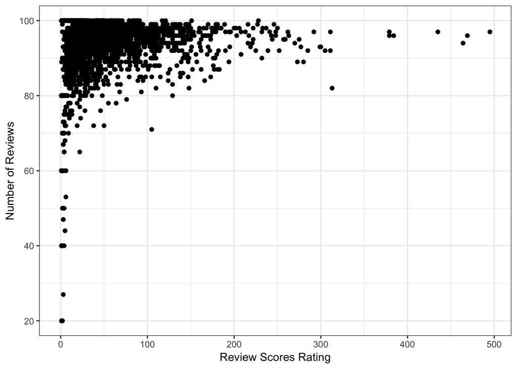

```r
ggplot(data=airbnb_dc,aes(x=number_of_reviews,y=review_scores_rating))+
  geom_point() + xlab("Review Scores Rating") + ylab("Number of Reviews") + theme_bw()
```

Again, we can use facets to look at how this varies across room_type:

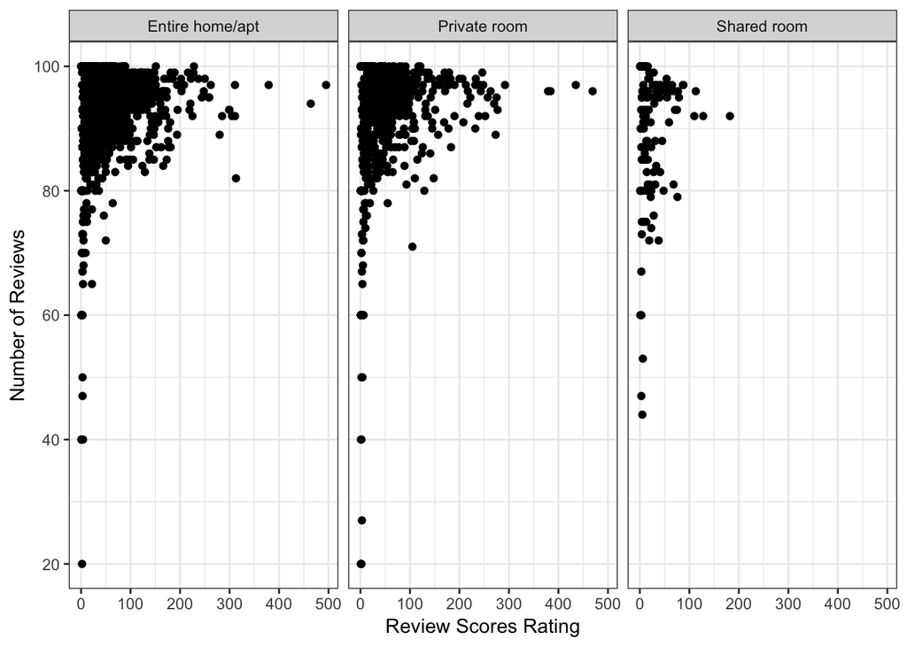

```r
ggplot(data=airbnb_dc,aes(x=number_of_reviews,y=review_scores_rating))+
  geom_point() + xlab("Review Scores Rating") + ylab("Number of Reviews") + theme_bw() + facet_wrap(~ room_type)
```

## Airbnb Data Analysis 8: Saving output

Suppose, we’ve done some computation, and we want to save our modified dataframe. We can use write_csv() to save our dataset as comma separated values file.

```r
airbnb_dc$price_gt_500 <- (airbnb_dc$price > 500)
write_csv(airbnb_dc, "data/modified_airbnb.csv")
```

## Additional resources for reproducible workflow

[Why setwd() is bad practice](https://www.tidyverse.org/articles/2017/12/workflow-vs-script/)

[Concise guide to basic computational reproducibility](https://kbroman.org/steps2rr/)

[Eight things you can do to make your open science more understandable](http://datacolada.org/69)

[A detailed guide to reproducible workflows in collaborative settings](http://journals.plos.org/ploscompbiol/article?id=10.1371/journal.pcbi.1005510)

[For more complicated projects, consider using make and docker](http://www.jonzelner.net/statistics/make/docker/reproducibility/2016/05/31/reproducibility-pt-1/)

## Exercises

1. What are the different types of cancellation policies offered at Airbnb?
2. What is the most common and least common cancellation policy?
3. What percent of Airbnb property types are houses? Hint: To find what percent of X is Y, use this formula: Y/X * 100
4. How many listings get a review rating below 50?
5. Try generating a scatterplot of price against bedrooms. Now add an overlay of a loess line. Now try creating subplots for each of the property types.
6. Try installing the visdat library, and explore different ways to visualize missing data.

## Feedback

[Let us know what you think of this lesson!](https://unc.az1.qualtrics.com/jfe/form/SV_8e1zRY2rlFUYBMx)